# Risk Factor Analysis

## Outcome Variable

**Outcome Variable:** wast_rec90d

## Predictor Variables

**Intervention Variable:** fage

**Adjustment Set:**

- arm
- W_mage
- meducyrs
- feducyrs
- W_mhtcm
- W_mwtkg
- W_mbmi
- W_fhtcm
- single
- brthmon
- delta_W_mage
- delta_meducyrs
- delta_feducyrs
- delta_W_mhtcm
- delta_W_mwtkg
- delta_W_mbmi
- delta_W_fhtcm
- delta_single
- delta_brthmon

## Stratifying Variables

The analysis was stratified on these variable(s):

- agecat
- studyid
- country

## Data Summary

| agecat | studyid | country | fage | wast_rec90d | n_cell | n |
| --- | --- | --- | --- | --- | --- | --- |
| 0-24 months | COHORTS | GUATEMALA | >=38 | 0 | 59 | 366 |
| 0-24 months | COHORTS | GUATEMALA | >=38 | 1 | 51 | 366 |
| 0-24 months | COHORTS | GUATEMALA | <32 | 0 | 86 | 366 |
| 0-24 months | COHORTS | GUATEMALA | <32 | 1 | 74 | 366 |
| 0-24 months | COHORTS | GUATEMALA | [32-38) | 0 | 57 | 366 |
| 0-24 months | COHORTS | GUATEMALA | [32-38) | 1 | 39 | 366 |
| 0-24 months | COHORTS | PHILIPPINES | >=38 | 0 | 83 | 1620 |
| 0-24 months | COHORTS | PHILIPPINES | >=38 | 1 | 114 | 1620 |
| 0-24 months | COHORTS | PHILIPPINES | <32 | 0 | 429 | 1620 |
| 0-24 months | COHORTS | PHILIPPINES | <32 | 1 | 703 | 1620 |
| 0-24 months | COHORTS | PHILIPPINES | [32-38) | 0 | 123 | 1620 |
| 0-24 months | COHORTS | PHILIPPINES | [32-38) | 1 | 168 | 1620 |
| 0-24 months | LCNI-5 | MALAWI | >=38 | 0 | 2 | 14 |
| 0-24 months | LCNI-5 | MALAWI | >=38 | 1 | 0 | 14 |
| 0-24 months | LCNI-5 | MALAWI | <32 | 0 | 7 | 14 |
| 0-24 months | LCNI-5 | MALAWI | <32 | 1 | 2 | 14 |
| 0-24 months | LCNI-5 | MALAWI | [32-38) | 0 | 3 | 14 |
| 0-24 months | LCNI-5 | MALAWI | [32-38) | 1 | 0 | 14 |
| 0-24 months | MAL-ED | BANGLADESH | >=38 | 0 | 12 | 77 |
| 0-24 months | MAL-ED | BANGLADESH | >=38 | 1 | 22 | 77 |
| 0-24 months | MAL-ED | BANGLADESH | <32 | 0 | 5 | 77 |
| 0-24 months | MAL-ED | BANGLADESH | <32 | 1 | 17 | 77 |
| 0-24 months | MAL-ED | BANGLADESH | [32-38) | 0 | 11 | 77 |
| 0-24 months | MAL-ED | BANGLADESH | [32-38) | 1 | 10 | 77 |
| 0-24 months | MAL-ED | BRAZIL | >=38 | 0 | 0 | 7 |
| 0-24 months | MAL-ED | BRAZIL | >=38 | 1 | 0 | 7 |
| 0-24 months | MAL-ED | BRAZIL | <32 | 0 | 0 | 7 |
| 0-24 months | MAL-ED | BRAZIL | <32 | 1 | 3 | 7 |
| 0-24 months | MAL-ED | BRAZIL | [32-38) | 0 | 2 | 7 |
| 0-24 months | MAL-ED | BRAZIL | [32-38) | 1 | 2 | 7 |

[output cut: 204 more lines]

The following strata were considered:

- agecat: 0-24 months, studyid: COHORTS, country: GUATEMALA
- agecat: 0-24 months, studyid: COHORTS, country: PHILIPPINES
- agecat: 0-24 months, studyid: LCNI-5, country: MALAWI
- agecat: 0-24 months, studyid: MAL-ED, country: BANGLADESH
- agecat: 0-24 months, studyid: MAL-ED, country: BRAZIL
- agecat: 0-24 months, studyid: MAL-ED, country: INDIA
- agecat: 0-24 months, studyid: MAL-ED, country: NEPAL
- agecat: 0-24 months, studyid: MAL-ED, country: PERU
- agecat: 0-24 months, studyid: MAL-ED, country: SOUTH AFRICA
- agecat: 0-24 months, studyid: MAL-ED, country: TANZANIA, UNITED REPUBLIC OF
- agecat: 0-24 months, studyid: PROBIT, country: BELARUS
- agecat: 0-24 months, studyid: SAS-CompFeed, country: INDIA
- agecat: 0-24 months, studyid: SAS-FoodSuppl, country: INDIA
- agecat: 0-6 months, studyid: COHORTS, country: GUATEMALA
- agecat: 0-6 months, studyid: COHORTS, country: PHILIPPINES
- agecat: 0-6 months, studyid: LCNI-5, country: MALAWI
- agecat: 0-6 months, studyid: MAL-ED, country: BANGLADESH
- agecat: 0-6 months, studyid: MAL-ED, country: BRAZIL
- agecat: 0-6 months, studyid: MAL-ED, country: INDIA
- agecat: 0-6 months, studyid: MAL-ED, country: NEPAL
- agecat: 0-6 months, studyid: MAL-ED, country: PERU
- agecat: 0-6 months, studyid: MAL-ED, country: SOUTH AFRICA
- agecat: 0-6 months, studyid: MAL-ED, country: TANZANIA, UNITED REPUBLIC OF
- agecat: 0-6 months, studyid: PROBIT, country: BELARUS
- agecat: 0-6 months, studyid: SAS-CompFeed, country: INDIA
- agecat: 0-6 months, studyid: SAS-FoodSuppl, country: INDIA
- agecat: 6-24 months, studyid: COHORTS, country: GUATEMALA
- agecat: 6-24 months, studyid: COHORTS, country: PHILIPPINES
- agecat: 6-24 months, studyid: LCNI-5, country: MALAWI
- agecat: 6-24 months, studyid: MAL-ED, country: BANGLADESH
- agecat: 6-24 months, studyid: MAL-ED, country: BRAZIL
- agecat: 6-24 months, studyid: MAL-ED, country: INDIA
- agecat: 6-24 months, studyid: MAL-ED, country: NEPAL
- agecat: 6-24 months, studyid: MAL-ED, country: PERU
- agecat: 6-24 months, studyid: MAL-ED, country: SOUTH AFRICA
- agecat: 6-24 months, studyid: MAL-ED, country: TANZANIA, UNITED REPUBLIC OF
- agecat: 6-24 months, studyid: PROBIT, country: BELARUS
- agecat: 6-24 months, studyid: SAS-CompFeed, country: INDIA
- agecat: 6-24 months, studyid: SAS-FoodSuppl, country: INDIA

### Dropped Strata

Some strata were dropped due to rare outcomes:

- agecat: 0-24 months, studyid: LCNI-5, country: MALAWI
- agecat: 0-24 months, studyid: MAL-ED, country: BRAZIL
- agecat: 0-24 months, studyid: MAL-ED, country: NEPAL
- agecat: 0-24 months, studyid: MAL-ED, country: PERU
- agecat: 0-24 months, studyid: MAL-ED, country: SOUTH AFRICA
- agecat: 0-24 months, studyid: MAL-ED, country: TANZANIA, UNITED REPUBLIC OF
- agecat: 0-24 months, studyid: SAS-FoodSuppl, country: INDIA
- agecat: 0-6 months, studyid: LCNI-5, country: MALAWI
- agecat: 0-6 months, studyid: MAL-ED, country: BANGLADESH
- agecat: 0-6 months, studyid: MAL-ED, country: BRAZIL
- agecat: 0-6 months, studyid: MAL-ED, country: INDIA
- agecat: 0-6 months, studyid: MAL-ED, country: NEPAL
- agecat: 0-6 months, studyid: MAL-ED, country: PERU
- agecat: 0-6 months, studyid: MAL-ED, country: SOUTH AFRICA
- agecat: 0-6 months, studyid: MAL-ED, country: TANZANIA, UNITED REPUBLIC OF
- agecat: 0-6 months, studyid: SAS-FoodSuppl, country: INDIA
- agecat: 6-24 months, studyid: COHORTS, country: GUATEMALA
- agecat: 6-24 months, studyid: LCNI-5, country: MALAWI
- agecat: 6-24 months, studyid: MAL-ED, country: BANGLADESH
- agecat: 6-24 months, studyid: MAL-ED, country: BRAZIL
- agecat: 6-24 months, studyid: MAL-ED, country: INDIA
- agecat: 6-24 months, studyid: MAL-ED, country: NEPAL
- agecat: 6-24 months, studyid: MAL-ED, country: PERU
- agecat: 6-24 months, studyid: MAL-ED, country: SOUTH AFRICA
- agecat: 6-24 months, studyid: MAL-ED, country: TANZANIA, UNITED REPUBLIC OF
- agecat: 6-24 months, studyid: PROBIT, country: BELARUS
- agecat: 6-24 months, studyid: SAS-FoodSuppl, country: INDIA

## Methods Detail

We’re interested in the causal parameters $E[Y_a]$ for all values of $a \in \mathcal{A}$. These parameters represent the mean outcome if, possibly contrary to fact, we intervened to set all units to have $A=a$. Under the randomization and positivity assumptions, these are identified by the statistical parameters $\psi_a=E_W[E_{Y|A,W}(Y|A=a,W)]$. In addition, we’re interested in the mean of $Y$, $E[Y]$ under no intervention (the observed mean). We will estimate these parameters by using SuperLearner to fit the relevant likelihood factors – $E_{Y|A,W}(Y|A=a,W)$ and $p(A=a|W)$, and then updating our likelihood fit using a joint TMLE.

For unadjusted analyses ($W=\{\}$), initial likelihoods were estimated using Lrnr_glm to estimate the simple $E(Y|A)$ and Lrnr_mean to estimate $p(A)$. For adjusted analyses, a small library containing Lrnr_glmnet, Lrnr_xgboost, and Lrnr_mean was used.

Having estimated these parameters, we will then use the delta method to estimate relative risks and attributable risks relative to a prespecified baseline level of $A$.

# Results Detail

## Results Plots

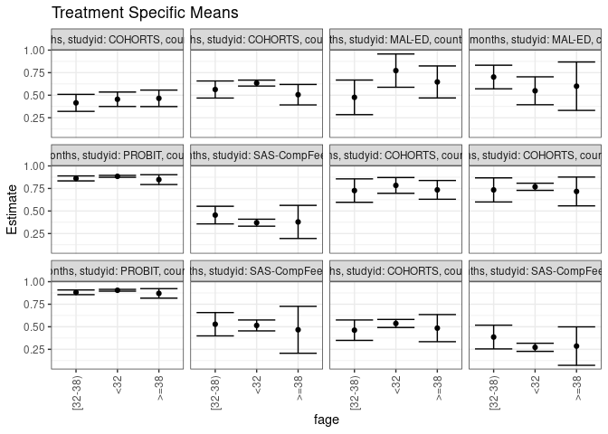

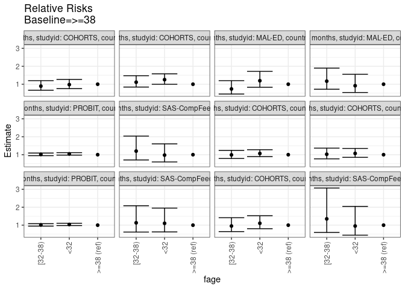

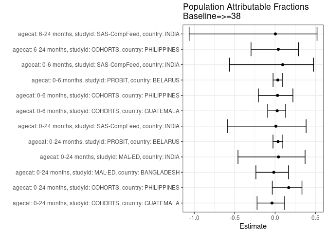

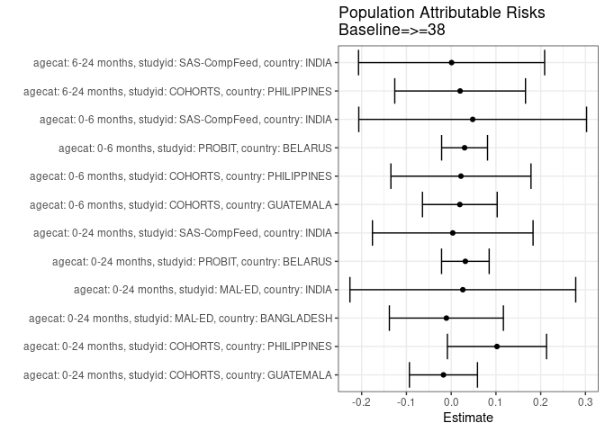

## Results Table

### Parameter: TSM

| agecat | studyid | country | intervention_level | baseline_level | estimate | ci_lower | ci_upper |
| --- | --- | --- | --- | --- | --- | --- | --- |
| 0-24 months | COHORTS | GUATEMALA | >=38 | NA | 0.4653661 | 0.3740724 | 0.5566599 |
| 0-24 months | COHORTS | GUATEMALA | <32 | NA | 0.4549180 | 0.3747915 | 0.5350445 |
| 0-24 months | COHORTS | GUATEMALA | [32-38) | NA | 0.4152413 | 0.3209498 | 0.5095327 |
| 0-24 months | COHORTS | PHILIPPINES | >=38 | NA | 0.5057200 | 0.3921761 | 0.6192639 |
| 0-24 months | COHORTS | PHILIPPINES | <32 | NA | 0.6345944 | 0.6017927 | 0.6673960 |
| 0-24 months | COHORTS | PHILIPPINES | [32-38) | NA | 0.5632675 | 0.4687642 | 0.6577708 |
| 0-24 months | MAL-ED | BANGLADESH | >=38 | NA | 0.6470588 | 0.4696719 | 0.8244457 |
| 0-24 months | MAL-ED | BANGLADESH | <32 | NA | 0.7727273 | 0.5883808 | 0.9570738 |
| 0-24 months | MAL-ED | BANGLADESH | [32-38) | NA | 0.4761905 | 0.2843868 | 0.6679942 |
| 0-24 months | MAL-ED | INDIA | >=38 | NA | 0.6000000 | 0.3314652 | 0.8685348 |
| 0-24 months | MAL-ED | INDIA | <32 | NA | 0.5490196 | 0.3942129 | 0.7038263 |
| 0-24 months | MAL-ED | INDIA | [32-38) | NA | 0.7017544 | 0.5709473 | 0.8325615 |
| 0-24 months | PROBIT | BELARUS | >=38 | NA | 0.8478880 | 0.7933919 | 0.9023840 |
| 0-24 months | PROBIT | BELARUS | <32 | NA | 0.8842675 | 0.8737120 | 0.8948230 |
| 0-24 months | PROBIT | BELARUS | [32-38) | NA | 0.8613554 | 0.8337326 | 0.8889781 |
| 0-24 months | SAS-CompFeed | INDIA | >=38 | NA | 0.3787172 | 0.1951518 | 0.5622826 |
| 0-24 months | SAS-CompFeed | INDIA | <32 | NA | 0.3701734 | 0.3315317 | 0.4088151 |
| 0-24 months | SAS-CompFeed | INDIA | [32-38) | NA | 0.4544330 | 0.3566046 | 0.5522613 |
| 0-6 months | COHORTS | GUATEMALA | >=38 | NA | 0.7342909 | 0.6303929 | 0.8381888 |
| 0-6 months | COHORTS | GUATEMALA | <32 | NA | 0.7836405 | 0.6960841 | 0.8711970 |
| 0-6 months | COHORTS | GUATEMALA | [32-38) | NA | 0.7263012 | 0.5965095 | 0.8560928 |
| 0-6 months | COHORTS | PHILIPPINES | >=38 | NA | 0.7166349 | 0.5568675 | 0.8764023 |
| 0-6 months | COHORTS | PHILIPPINES | <32 | NA | 0.7683786 | 0.7287582 | 0.8079990 |
| 0-6 months | COHORTS | PHILIPPINES | [32-38) | NA | 0.7337476 | 0.6003204 | 0.8671748 |
| 0-6 months | PROBIT | BELARUS | >=38 | NA | 0.8701477 | 0.8176105 | 0.9226850 |
| 0-6 months | PROBIT | BELARUS | <32 | NA | 0.9046028 | 0.8945739 | 0.9146317 |
| 0-6 months | PROBIT | BELARUS | [32-38) | NA | 0.8820689 | 0.8560461 | 0.9080916 |
| 0-6 months | SAS-CompFeed | INDIA | >=38 | NA | 0.4666667 | 0.2061538 | 0.7271796 |
| 0-6 months | SAS-CompFeed | INDIA | <32 | NA | 0.5147059 | 0.4543062 | 0.5751055 |
| 0-6 months | SAS-CompFeed | INDIA | [32-38) | NA | 0.5283019 | 0.3989989 | 0.6576049 |
| 6-24 months | COHORTS | PHILIPPINES | >=38 | NA | 0.4849707 | 0.3344420 | 0.6354993 |
| 6-24 months | COHORTS | PHILIPPINES | <32 | NA | 0.5365809 | 0.4919504 | 0.5812114 |
| 6-24 months | COHORTS | PHILIPPINES | [32-38) | NA | 0.4622669 | 0.3490447 | 0.5754892 |
| 6-24 months | SAS-CompFeed | INDIA | >=38 | NA | 0.2857143 | 0.0723858 | 0.4990428 |
| 6-24 months | SAS-CompFeed | INDIA | <32 | NA | 0.2722646 | 0.2273817 | 0.3171476 |
| 6-24 months | SAS-CompFeed | INDIA | [32-38) | NA | 0.3859649 | 0.2542449 | 0.5176849 |

### Parameter: E(Y)

| agecat | studyid | country | intervention_level | baseline_level | estimate | ci_lower | ci_upper |
| --- | --- | --- | --- | --- | --- | --- | --- |
| 0-24 months | COHORTS | GUATEMALA | NA | NA | 0.4480874 | 0.3954108 | 0.5007641 |
| 0-24 months | COHORTS | PHILIPPINES | NA | NA | 0.6080247 | 0.5830213 | 0.6330281 |
| 0-24 months | MAL-ED | BANGLADESH | NA | NA | 0.6363636 | 0.5243346 | 0.7483927 |
| 0-24 months | MAL-ED | INDIA | NA | NA | 0.6260163 | 0.5320687 | 0.7199638 |
| 0-24 months | PROBIT | BELARUS | NA | NA | 0.8795923 | 0.8698558 | 0.8893288 |
| 0-24 months | SAS-CompFeed | INDIA | NA | NA | 0.3822441 | 0.3470990 | 0.4173892 |
| 0-6 months | COHORTS | GUATEMALA | NA | NA | 0.7536232 | 0.6949302 | 0.8123162 |
| 0-6 months | COHORTS | PHILIPPINES | NA | NA | 0.7384615 | 0.7062339 | 0.7706892 |
| 0-6 months | PROBIT | BELARUS | NA | NA | 0.9000735 | 0.8908226 | 0.9093244 |
| 0-6 months | SAS-CompFeed | INDIA | NA | NA | 0.5147059 | 0.4610948 | 0.5683169 |
| 6-24 months | COHORTS | PHILIPPINES | NA | NA | 0.5049724 | 0.4705318 | 0.5394130 |
| 6-24 months | SAS-CompFeed | INDIA | NA | NA | 0.2866242 | 0.2446853 | 0.3285631 |

### Parameter: RR

| agecat | studyid | country | intervention_level | baseline_level | estimate | ci_lower | ci_upper |
| --- | --- | --- | --- | --- | --- | --- | --- |
| 0-24 months | COHORTS | GUATEMALA | >=38 | >=38 | 1.0000000 | 1.0000000 | 1.000000 |
| 0-24 months | COHORTS | GUATEMALA | <32 | >=38 | 0.9775486 | 0.7544540 | 1.266613 |
| 0-24 months | COHORTS | GUATEMALA | [32-38) | >=38 | 0.8922894 | 0.6645528 | 1.198069 |
| 0-24 months | COHORTS | PHILIPPINES | >=38 | >=38 | 1.0000000 | 1.0000000 | 1.000000 |
| 0-24 months | COHORTS | PHILIPPINES | <32 | >=38 | 1.2548335 | 0.9966393 | 1.579917 |
| 0-24 months | COHORTS | PHILIPPINES | [32-38) | >=38 | 1.1137932 | 0.8415639 | 1.474083 |
| 0-24 months | MAL-ED | BANGLADESH | >=38 | >=38 | 1.0000000 | 1.0000000 | 1.000000 |
| 0-24 months | MAL-ED | BANGLADESH | <32 | >=38 | 1.1942149 | 0.8303676 | 1.717491 |
| 0-24 months | MAL-ED | BANGLADESH | [32-38) | >=38 | 0.7359307 | 0.4521186 | 1.197903 |
| 0-24 months | MAL-ED | INDIA | >=38 | >=38 | 1.0000000 | 1.0000000 | 1.000000 |
| 0-24 months | MAL-ED | INDIA | <32 | >=38 | 0.9150327 | 0.5384477 | 1.554997 |
| 0-24 months | MAL-ED | INDIA | [32-38) | >=38 | 1.1695906 | 0.7206230 | 1.898277 |
| 0-24 months | PROBIT | BELARUS | >=38 | >=38 | 1.0000000 | 1.0000000 | 1.000000 |
| 0-24 months | PROBIT | BELARUS | <32 | >=38 | 1.0429060 | 0.9769041 | 1.113367 |
| 0-24 months | PROBIT | BELARUS | [32-38) | >=38 | 1.0158835 | 0.9454881 | 1.091520 |
| 0-24 months | SAS-CompFeed | INDIA | >=38 | >=38 | 1.0000000 | 1.0000000 | 1.000000 |
| 0-24 months | SAS-CompFeed | INDIA | <32 | >=38 | 0.9774401 | 0.5956725 | 1.603883 |
| 0-24 months | SAS-CompFeed | INDIA | [32-38) | >=38 | 1.1999269 | 0.7065307 | 2.037880 |
| 0-6 months | COHORTS | GUATEMALA | >=38 | >=38 | 1.0000000 | 1.0000000 | 1.000000 |
| 0-6 months | COHORTS | GUATEMALA | <32 | >=38 | 1.0672073 | 0.8926029 | 1.275966 |
| 0-6 months | COHORTS | GUATEMALA | [32-38) | >=38 | 0.9891192 | 0.7879626 | 1.241628 |
| 0-6 months | COHORTS | PHILIPPINES | >=38 | >=38 | 1.0000000 | 1.0000000 | 1.000000 |
| 0-6 months | COHORTS | PHILIPPINES | <32 | >=38 | 1.0722037 | 0.8529699 | 1.347786 |
| 0-6 months | COHORTS | PHILIPPINES | [32-38) | >=38 | 1.0238793 | 0.7678768 | 1.365230 |
| 0-6 months | PROBIT | BELARUS | >=38 | >=38 | 1.0000000 | 1.0000000 | 1.000000 |
| 0-6 months | PROBIT | BELARUS | <32 | >=38 | 1.0395968 | 0.9777003 | 1.105412 |
| 0-6 months | PROBIT | BELARUS | [32-38) | >=38 | 1.0137001 | 0.9478263 | 1.084152 |
| 0-6 months | SAS-CompFeed | INDIA | >=38 | >=38 | 1.0000000 | 1.0000000 | 1.000000 |
| 0-6 months | SAS-CompFeed | INDIA | <32 | >=38 | 1.1029412 | 0.6234654 | 1.951158 |
| 0-6 months | SAS-CompFeed | INDIA | [32-38) | >=38 | 1.1320755 | 0.6153979 | 2.082547 |
| 6-24 months | COHORTS | PHILIPPINES | >=38 | >=38 | 1.0000000 | 1.0000000 | 1.000000 |
| 6-24 months | COHORTS | PHILIPPINES | <32 | >=38 | 1.1064194 | 0.8024113 | 1.525607 |
| 6-24 months | COHORTS | PHILIPPINES | [32-38) | >=38 | 0.9531854 | 0.6416061 | 1.416075 |
| 6-24 months | SAS-CompFeed | INDIA | >=38 | >=38 | 1.0000000 | 1.0000000 | 1.000000 |
| 6-24 months | SAS-CompFeed | INDIA | <32 | >=38 | 0.9529262 | 0.4435900 | 2.047089 |
| 6-24 months | SAS-CompFeed | INDIA | [32-38) | >=38 | 1.3508772 | 0.5944071 | 3.070066 |

### Parameter: PAR

| agecat | studyid | country | intervention_level | baseline_level | estimate | ci_lower | ci_upper |
| --- | --- | --- | --- | --- | --- | --- | --- |
| 0-24 months | COHORTS | GUATEMALA | >=38 | NA | -0.0172787 | -0.0933138 | 0.0587564 |
| 0-24 months | COHORTS | PHILIPPINES | >=38 | NA | 0.1023047 | -0.0084327 | 0.2130420 |
| 0-24 months | MAL-ED | BANGLADESH | >=38 | NA | -0.0106952 | -0.1380673 | 0.1166770 |
| 0-24 months | MAL-ED | INDIA | >=38 | NA | 0.0260163 | -0.2262080 | 0.2782405 |
| 0-24 months | PROBIT | BELARUS | >=38 | NA | 0.0317044 | -0.0214731 | 0.0848819 |
| 0-24 months | SAS-CompFeed | INDIA | >=38 | NA | 0.0035269 | -0.1758971 | 0.1829510 |
| 0-6 months | COHORTS | GUATEMALA | >=38 | NA | 0.0193323 | -0.0641235 | 0.1027881 |
| 0-6 months | COHORTS | PHILIPPINES | >=38 | NA | 0.0218267 | -0.1346575 | 0.1783109 |
| 0-6 months | PROBIT | BELARUS | >=38 | NA | 0.0299258 | -0.0213406 | 0.0811921 |
| 0-6 months | SAS-CompFeed | INDIA | >=38 | NA | 0.0480392 | -0.2064266 | 0.3025050 |
| 6-24 months | COHORTS | PHILIPPINES | >=38 | NA | 0.0200017 | -0.1260426 | 0.1660460 |
| 6-24 months | SAS-CompFeed | INDIA | >=38 | NA | 0.0009099 | -0.2069616 | 0.2087814 |

### Parameter: PAF

| agecat | studyid | country | intervention_level | baseline_level | estimate | ci_lower | ci_upper |
| --- | --- | --- | --- | --- | --- | --- | --- |
| 0-24 months | COHORTS | GUATEMALA | >=38 | NA | -0.0385610 | -0.2231173 | 0.1181476 |
| 0-24 months | COHORTS | PHILIPPINES | >=38 | NA | 0.1682575 | -0.0355180 | 0.3319327 |
| 0-24 months | MAL-ED | BANGLADESH | >=38 | NA | -0.0168067 | -0.2377087 | 0.1646694 |
| 0-24 months | MAL-ED | INDIA | >=38 | NA | 0.0415584 | -0.4592634 | 0.3704973 |
| 0-24 months | PROBIT | BELARUS | >=38 | NA | 0.0360444 | -0.0263694 | 0.0946628 |
| 0-24 months | SAS-CompFeed | INDIA | >=38 | NA | 0.0092269 | -0.5912456 | 0.3831051 |
| 0-6 months | COHORTS | GUATEMALA | >=38 | NA | 0.0256525 | -0.0917334 | 0.1304168 |
| 0-6 months | COHORTS | PHILIPPINES | >=38 | NA | 0.0295570 | -0.2072695 | 0.2199259 |
| 0-6 months | PROBIT | BELARUS | >=38 | NA | 0.0332481 | -0.0254400 | 0.0885774 |
| 0-6 months | SAS-CompFeed | INDIA | >=38 | NA | 0.0933333 | -0.5644012 | 0.4745309 |
| 6-24 months | COHORTS | PHILIPPINES | >=38 | NA | 0.0396095 | -0.2979402 | 0.2893741 |
| 6-24 months | SAS-CompFeed | INDIA | >=38 | NA | 0.0031746 | -1.0634622 | 0.5184497 |